# 2

2024-05-01

# 数据建模（DESeqDataSetFromMatrix 和 DESeq）

`DESeq2` 采用一个模型将基因表达数据建模为负二项分布，这是因为负二项分布能够有效地处理表达数据的过度离散性（即方差大于均值的现象）。核心的模型如下：

$$Y_{ij} \sim NB(\mu_{ij}, \alpha_j)$$

其中：

- $Y_{ij}$ 是第 $i$ 个样本中第 $j$ 个基因的读数。
- $\mu_{ij}$ 是该基因的期望读数，它依赖于样本的效应（如实验条件）和基因特有的效应。
- $\alpha_j$ 是与第 $j$ 个基因相关的离散参数。

期望读数 $\mu_{ij}$ 通常通过以下公式计算：

$$\mu_{ij} = s_i \cdot q_{ij}$$

- $s_i$ 是样本 $i$ 的大小因子，用于校正测序深度的不同。
- $q_{ij}$ 是经过转换（对数变换）和模型拟合后的基因表达水平。

## 差异表达分析

`DESeq` 函数进行的分析基于对数比率检验（log-ratio test），是评估不同条件下基因表达的对数变化率。公式：

$$\log_2\left(\frac{\mu_{ij,\text{Late}}}{\mu_{ij,\text{Early}}}\right)$$

## 结果排序和P值

`DESeq2` 提供的结果中，P值是通过Wald测试或似然比测试计算得出的，评估模型中的不同条件下的对数变化是否显著不为零。在处理完毕后，P值进行校正以控制多重比较问题，使用的是Benjamini-Hochberg方法来调整错误发现率（FDR）。

## MA-Plot的绘制

MA-plot是一种用于展示基因表达差异的图形，其中M代表对数变化率（log ratio），A代表平均表达水平的对数。

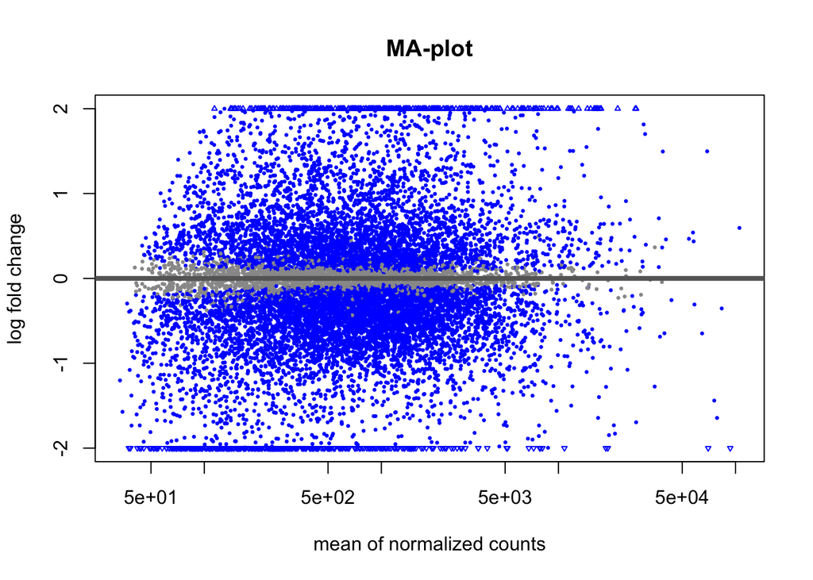

```r
library(DESeq2)

# 读取数据
early_stage <- read.csv("/Users/yooky/Desktop/建模/基因/附件2：EarlyStage_exp.csv", header=TRUE, row.names=1)
normal_stage <- read.csv("/Users/yooky/Desktop/建模/基因/附件1：Normal_exp.csv", header=TRUE, row.names=1)

# 创建DESeq2矩阵格式
countData <- cbind(normal_stage, early_stage)
colData <- data.frame(condition = factor(c(rep("Normal", ncol(normal_stage)), rep("Early", ncol(early_stage)))))

# 构建DESeq对象
dds <- DESeqDataSetFromMatrix(countData = countData, colData = colData, design = ~ condition)
dds <- DESeq(dds)

# 获取差异表达基因
res <- results(dds)

# 筛选padj<0.05的基因
significant_genes <- res[res$padj < 0.05, ]

# 将结果写入CSV文件
write.csv(as.data.frame(significant_genes), file="/Users/yooky/Desktop/建模/基因/Differential_Expression_Early_Normal.csv")

# 生成MA-plot
plotMA(dds, main="MA-plot", ylim=c(-2, 2))
```

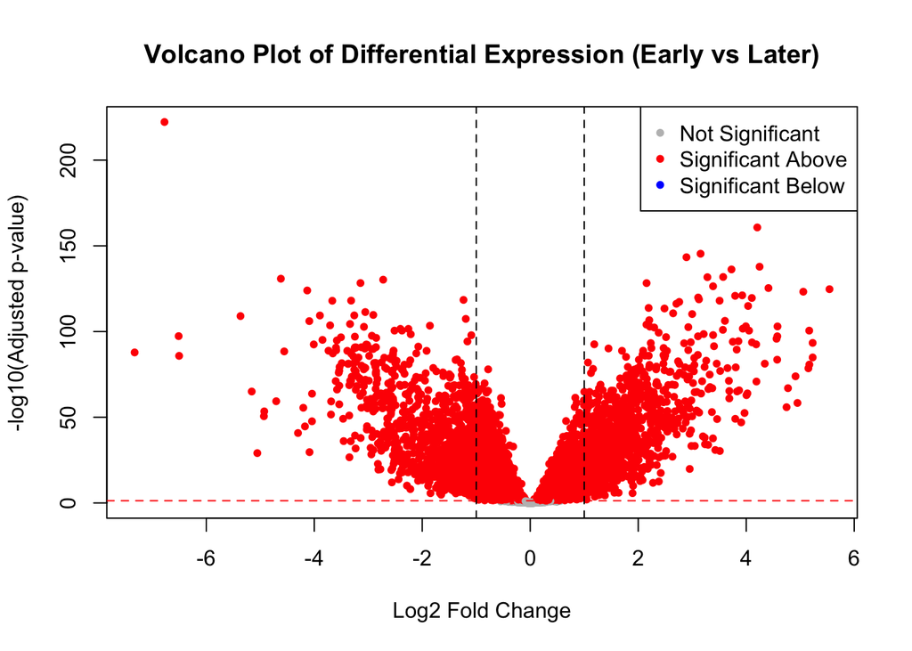

```r
volcano_plot <- function(res, title) {
  # 定义显著性阈值
  alpha <- 0.05
  log2_fc_threshold <- 1
  log_p_threshold <- -log10(alpha)

  # 计算每个点是否显著
  significant <- res$padj < alpha & abs(res$log2FoldChange) > log2_fc_threshold

  # 进一步根据 -log10(padj) 值决定颜色
  point_colors <- ifelse(res$padj < alpha, ifelse(-log10(res$padj) > log_p_threshold, "red", "blue"), "gray")

  # 绘制火山图
  plot(res$log2FoldChange, -log10(res$padj),
       pch=20,
       col=point_colors,  # 使用显著性来设定颜色
       xlab="Log2 Fold Change",
       ylab="-log10(Adjusted p-value)",
       main=title)

  # 添加显著性阈值线
  abline(h=log_p_threshold, col="red", lty=2)  # 红色线表示p-value阈值
  abline(v=c(-log2_fc_threshold, log2_fc_threshold), col="black", lty=2)  # 黑色线表示Fold Change阈值

  # 添加图例
  legend("topright", legend=c("Not Significant", "Significant Above", "Significant Below"),
         col=c("gray", "red", "blue"), pch=20)
}
if ("padj" %in% colnames(res) && "log2FoldChange" %in% colnames(res)) {
  volcano_plot(res, title="Volcano Plot of Differential Expression (Early vs Later)")
} else {
  print("The data object 'res' does not have the necessary columns.")
}
```

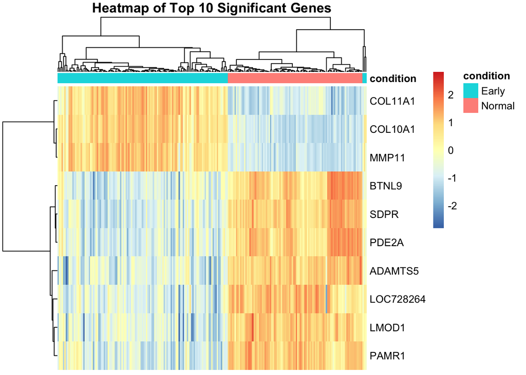

```r
library(pheatmap)
# 筛选padj<0.05的基因并排序
significant_genes <- res[res$padj < 0.05, ]
top_genes <- head(significant_genes[order(significant_genes$padj), ], 10)

# 获取顶部基因的名称
top_gene_names <- rownames(top_genes)

# 提取这些基因的表达数据
top_gene_data <- assay(dds)[top_gene_names, ]


# 确保colData中包含正确的注释信息
colData <- data.frame(condition = factor(c(rep("Normal", ncol(normal_stage)), rep("Early", ncol(early_stage)))),
                      row.names = colnames(countData))

# 绘制热图
pheatmap(log2(top_gene_data + 1),
         scale = "row",
         clustering_distance_rows = "correlation",
         clustering_distance_cols = "correlation",
         annotation_col = colData,  # 确保这里的colData已经正确设置
         show_rownames = TRUE,
         show_colnames = FALSE,
         main = "Heatmap of Top 10 Significant Genes")
```